# Spotify Songs - Data Analysis

Dalia Smyrnov and Shir keynan

July 2020

[figure not shown]

# Introduction

In this research we will concentrate on the spotify songs data set.  
This dataset comes from Spotify via the spotifyr package, and it contains a lot of interesting information about the songs such as: popularity, danceability, key, etc.

We will focus on:  
1. Tidy our dataset.  
2. Visualizations.  
3. Statstical Models and methods learned during the course.

So, our goals is to demonstrate and practice the different methods which we have been learnd about in the course by examining the relationship between the different variables from the spotify songs dataset.

The methods which we will use in this research are:  
1. Hypothesis test.  
2. Model of multiple regression.

# Part One - Data Import And Tidying

```r
library(tidyverse) #main package
```

```r
library(prettydoc) #design
library(gridExtra) #for grid.arrange
library(ggcorrplot) #for correlation plot
```

The spotify songs data set is taken from tidytuesday and [spotifyr package](https://cran.r-project.org/src/contrib/Archive/spotifyr/) which based on the data from [Spotifys’ API](https://developer.spotify.com/documentation/web-api/). The data comes in a [CSV file](https://raw.githubusercontent.com/rfordatascience/tidytuesday/master/data/2020/2020-01-21/spotify_songs.csv).  
lets read this file with `read.csv` function that imports the data into R.

```r
spotify_songs <- readr::read_csv('https://raw.githubusercontent.com/rfordatascience/tidytuesday/master/data/2020/2020-01-21/spotify_songs.csv')
```

first, we need to get to know our data set.  
for this purpose we will look at our data set briefly, with `glimpse()` function.

```r
glimpse(spotify_songs)
```

```
## Observations: 32,833
## Variables: 23
## $ track_id                 <chr> "6f807x0ima9a1j3VPbc7VN", "0r7CVbZTWZgbTCY...
## $ track_name               <chr> "I Don't Care (with Justin Bieber) - Loud ...
## $ track_artist             <chr> "Ed Sheeran", "Maroon 5", "Zara Larsson", ...
## $ track_popularity         <dbl> 66, 67, 70, 60, 69, 67, 62, 69, 68, 67, 58...
## $ track_album_id           <chr> "2oCs0DGTsRO98Gh5ZSl2Cx", "63rPSO264uRjW1X...
## $ track_album_name         <chr> "I Don't Care (with Justin Bieber) [Loud L...
## $ track_album_release_date <chr> "2019-06-14", "2019-12-13", "2019-07-05", ...
## $ playlist_name            <chr> "Pop Remix", "Pop Remix", "Pop Remix", "Po...
## $ playlist_id              <chr> "37i9dQZF1DXcZDD7cfEKhW", "37i9dQZF1DXcZDD...
## $ playlist_genre           <chr> "pop", "pop", "pop", "pop", "pop", "pop", ...
## $ playlist_subgenre        <chr> "dance pop", "dance pop", "dance pop", "da...
## $ danceability             <dbl> 0.748, 0.726, 0.675, 0.718, 0.650, 0.675, ...
## $ energy                   <dbl> 0.916, 0.815, 0.931, 0.930, 0.833, 0.919, ...
## $ key                      <dbl> 6, 11, 1, 7, 1, 8, 5, 4, 8, 2, 6, 8, 1, 5,...
## $ loudness                 <dbl> -2.634, -4.969, -3.432, -3.778, -4.672, -5...
## $ mode                     <dbl> 1, 1, 0, 1, 1, 1, 0, 0, 1, 1, 1, 1, 1, 0, ...
## $ speechiness              <dbl> 0.0583, 0.0373, 0.0742, 0.1020, 0.0359, 0....
## $ acousticness             <dbl> 0.10200, 0.07240, 0.07940, 0.02870, 0.0803...
## $ instrumentalness         <dbl> 0.00e+00, 4.21e-03, 2.33e-05, 9.43e-06, 0....
## $ liveness                 <dbl> 0.0653, 0.3570, 0.1100, 0.2040, 0.0833, 0....
## $ valence                  <dbl> 0.518, 0.693, 0.613, 0.277, 0.725, 0.585, ...
## $ tempo                    <dbl> 122.036, 99.972, 124.008, 121.956, 123.976...
## $ duration_ms              <dbl> 194754, 162600, 176616, 169093, 189052, 16...
```

Here is a table which contains description about every data type, including theorethical and numeric scale explanations:

| variable | class | description |
| --- | --- | --- |
| track_id | character | Song unique ID |
| track_name | character | Song Name |
| track_artist | character | Song Artist |
| track_popularity | double | Song Popularity (0-100) where higher is better |
| track_album_id | character | Album unique ID |
| track_album_name | character | Song album name |
| track_album_release_date | character | Date when album released |
| playlist_name | character | Name of playlist |
| playlist_id | character | Playlist ID |
| playlist_genre | character | Playlist genre |
| playlist_subgenre | character | Playlist subgenre |
| danceability | double | Danceability describes how suitable a track is for dancing based on a combination of musical elements including tempo, rhythm stability, beat strength, and overall regularity. A value of 0.0 is least … |
| energy | double | Energy is a measure from 0.0 to 1.0 and represents a perceptual measure of intensity and activity. Typically, energetic tracks feel fast, loud, and noisy. For example, death metal has high energy, whi… |
| key | double | The estimated overall key of the track. Integers map to pitches using standard Pitch Class notation . E.g. 0 = C, 1 = C♯/D♭, 2 = D, and so on. If no key was detected, the value is -1. |
| loudness | double | The overall loudness of a track in decibels (dB). Loudness values are averaged across the entire track and are useful for comparing relative loudness of tracks. Loudness is the quality of a sound that… |
| mode | double | Mode indicates the modality (major or minor) of a track, the type of scale from which its melodic content is derived. Major is represented by 1 and minor is 0. |
| speechiness | double | Speechiness detects the presence of spoken words in a track. The more exclusively speech-like the recording (e.g. talk show, audio book, poetry), the closer to 1.0 the attribute value. Values above 0.… |
| acousticness | double | A confidence measure from 0.0 to 1.0 of whether the track is acoustic. 1.0 represents high confidence the track is acoustic. |
| instrumentalness | double | Predicts whether a track contains no vocals. “Ooh” and “aah” sounds are treated as instrumental in this context. Rap or spoken word tracks are clearly “vocal”. The closer the instrumentalness value is… |
| liveness | double | Detects the presence of an audience in the recording. Higher liveness values represent an increased probability that the track was performed live. A value above 0.8 provides strong likelihood that the… |
| valence | double | A measure from 0.0 to 1.0 describing the musical positiveness conveyed by a track. Tracks with high valence sound more positive (e.g. happy, cheerful, euphoric), while tracks with low valence sound mo… |
| tempo | double | The overall estimated tempo of a track in beats per minute (BPM). In musical terminology, tempo is the speed or pace of a given piece and derives directly from the average beat duration. |
| duration_ms | double | Duration of song in milliseconds. |

From our perspective, there are some problems with this data set:  
(1) Different playlists can contain the same song, which creates duplications in our data set. also, it can cause different genres for one song.  
(2) The duration of song represented by miliseconds. it is unconvenient way of time representing.  
(3) The release date of song looks like: year-month-day. it is problematic representation for us to analyse the data in this way.

```r
#delete all the information related to the playlists
spotify_songs$playlist_name <- NULL
spotify_songs$playlist_genre <- NULL
spotify_songs$playlist_id <- NULL
spotify_songs$playlist_subgenre <- NULL

#drop all duplicated tracks
tidy_spotify <- spotify_songs[!duplicated(spotify_songs$track_id),]
tidy_spotify <- spotify_songs[!duplicated(spotify_songs$track_name),]

#convertion of the song duration from miliseconds to minutes
spotify_songs <- mutate(spotify_songs,
       dur_min = duration_ms*(10^(-5)))
tidy_spotify <- mutate(tidy_spotify,
       dur_min = duration_ms*(10^(-5)))

#delete the duration in miliseconds from the dataset
tidy_spotify$duration_ms <- NULL

#tidy tha release date (year and month)
year_cut <- substring(tidy_spotify$track_album_release_date, 0, 4)
month_cut <- substring(tidy_spotify$track_album_release_date, 6, 7)
tidy_spotify <- tidy_spotify %>%
  mutate(year = year_cut)
```

```r
#reduction of the data: we interested in songs above 30 sec of duration
#                      and songs which published after 2000
tidy_spotify <- tidy_spotify %>% filter(dur_min > 2)
tidy_spotify <- tidy_spotify %>% filter(year >= 2000)
```

# Part Two - Visualizations

In this part we will examine our data through differrent graphs and plot with [ggplot2 package](https://www.rdocumentation.org/packages/ggplot2/versions/3.3.1).

### 1. The distributions of diffrenent variables

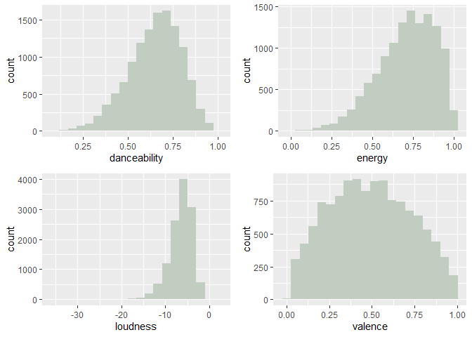

```r
dance_dist <- ggplot(tidy_spotify, aes(x=danceability)) +
  geom_histogram(bins=20, fill="honeydew3")

energy_dist <- ggplot(tidy_spotify, aes(x=energy)) +
  geom_histogram(bins=20, fill="honeydew3")

loudness_dist <- ggplot(tidy_spotify, aes(x=loudness)) +
  geom_histogram(bins=20, fill="honeydew3")

valence_dist <- ggplot(tidy_spotify, aes(x=valence)) +
  geom_histogram(bins=20, fill="honeydew3")

grid.arrange(dance_dist, energy_dist,loudness_dist,valence_dist)
```

As we can see, the danceability and valence remind a little the shape of normal distribution, but it is not accurate.

### 2. The density of diffrenent variables

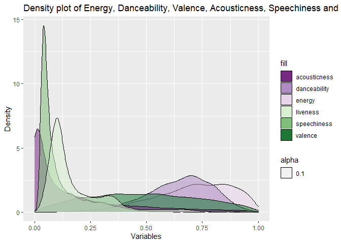

```r
spotify_density <- ggplot(tidy_spotify) +
    geom_density(aes(energy, fill ="energy", alpha = 0.1)) +
    geom_density(aes(danceability, fill ="danceability", alpha = 0.1)) +
    geom_density(aes(valence, fill ="valence", alpha = 0.1)) +
    geom_density(aes(acousticness, fill ="acousticness", alpha = 0.1)) +
    geom_density(aes(speechiness, fill ="speechiness", alpha = 0.1)) +
    geom_density(aes(liveness, fill ="liveness", alpha = 0.1)) +
    scale_x_continuous(name = "Variables") +
    scale_y_continuous(name = "Density") +
    ggtitle("Density plot of Energy, Danceability, Valence, Acousticness, Speechiness and Liveness") +
      scale_fill_brewer(palette="PRGn")

spotify_density
```

### 3. QQplot

Although some of the variables appear to be “normal”, we can be more confident about this statement if we wiil check it with the `qqplot` graph. (which is a graphical method for comparing two probability distributions by plotting their quantiles against each other.)  
If the variable distributes normally, we will see a Clear diagonal line.

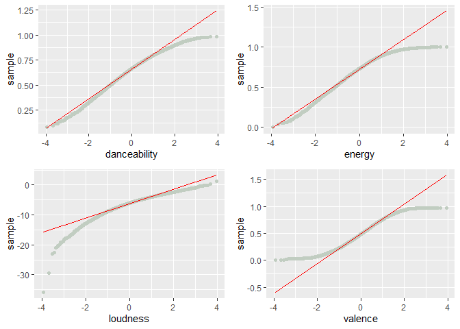

```r
dance_qq <- ggplot(tidy_spotify, aes(sample=danceability)) +
  geom_qq(color = "honeydew3") + geom_qq_line(col="red") +
    labs(x= "danceability")

energy_qq <- ggplot(tidy_spotify, aes(sample=energy)) +
  geom_qq(color = "honeydew3") + geom_qq_line(col="red") +
  labs(x= "energy")

loudness_qq <- ggplot(tidy_spotify, aes(sample=loudness)) +
  geom_qq(color = "honeydew3") + geom_qq_line(col="red") +
  labs(x= "loudness")

valence_qq <- ggplot(tidy_spotify, aes(sample=valence)) +
  geom_qq(color = "honeydew3") + geom_qq_line(col="red") +
  labs(x = "valence")

grid.arrange(dance_qq,energy_qq,loudness_qq,valence_qq)
```

Again, danceability is looks the most close to be normal, but it is not accurate.

### 4. Histogram of duration of different songs

```r
min_hist <- ggplot(spotify_songs, aes(dur_min))+
  geom_histogram(fill = "honeydew3")

min_boxplot <- ggplot(spotify_songs, aes(dur_min))+
  geom_boxplot(fill = "honeydew3")

mean(spotify_songs$dur_min)
```

```
## [1] 2.257998
```

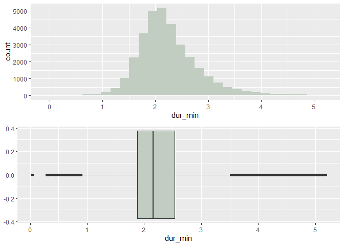

```r
grid.arrange(min_hist, min_boxplot)
```

# Part Three - Modeling

## First Model - Paired test

**Paired samples** (also called dependent samples) are samples in which natural or matched couplings occur. This generates a data set in which each data point in one sample is uniquely paired to a data point in the second sample.

We noticed that there are two different groups for the same song - remix, and the original song.  
We wanted to be able to compare the differences values between the two versions. for this purpose we used [python pandas package](https://pandas.pydata.org/docs/) :

```
spot.drop(['playlist_name', 'playlist_id','playlist_genre','playlist_subgenre'], axis=1, inplace=True)
#Drop duplicates under 'Track_name'
spot.drop_duplicates(subset = ['track_name'])
spot['track_name'] = spot['track_name'].str.lower()
spot['track_name'] = spot['track_name'].str.replace('mix','remix')

remix = spot[spot['track_name'].str.contains("remix",na=False)].copy()
original = spot[~spot['track_name'].str.contains("remix",na=False)].copy()

remix['track_name_edited'] = remix['track_name'].str.replace('Remix','') #Remove "Remix" from track name
remix['track_name_edited'] = remix['track_name'].str.replace('remix','') #Remove "remix" from track name
remix['track_name_edited'] = remix['track_name'].str.lower() #Change track name to lower case

remix['track_name_edited'] = remix['track_name_edited'].str.split('-').str[0] #Remove anything after "-"
remix['track_name_edited'] = remix['track_name_edited'].str.split('(').str[0] #Remove anything after "("
remix['track_name_edited'] = remix['track_name_edited'].str.split('[').str[0] #Remove anything after "["
remix.drop_duplicates(subset = ['track_name_edited'])
#####

original['track_name_edited'] = original['track_name'].str.lower() #Change track name to lower case

original['track_name_edited'] = original['track_name_edited'].str.split('-').str[0] #Remove anything after "-"
original['track_name_edited'] = original['track_name_edited'].str.split('(').str[0] #Remove anything after "("
original['track_name_edited'] = original['track_name_edited'].str.split('[').str[0] #Remove anything after "["


original.drop(['track_popularity','track_album_id','track_album_name','track_album_release_date'], axis=1, inplace=True)
remix.drop(['track_id','track_popularity','track_album_id','track_album_name','track_album_release_date'], axis=1, inplace=True)
remix.drop(['mode','loudness','duration_ms','tempo','key'], axis=1, inplace=True)
original.drop(['track_id','mode','loudness','duration_ms','tempo','key'], axis=1, inplace=True)
original.drop_duplicates(subset = ['track_name_edited'])

pd.set_option('display.max_columns', None)
pd.set_option('display.max_rows', None)

original.drop_duplicates(subset = ['track_name_edited'])
remix.drop_duplicates(subset = ['track_name_edited'])
a = pd.merge(remix, original.drop_duplicates(subset=['track_name_edited'], keep='first'), on= ['track_name_edited','track_artist'],how='left')
a = a.dropna()
a.drop(['track_name_x','instrumentalness_x','acousticness_x','liveness_x','speechiness_x'], axis=1, inplace=True)
a.drop(['track_name_y','instrumentalness_y','acousticness_y','liveness_y','speechiness_y'], axis=1, inplace=True)
a.drop(['danceability_x','valence_x','danceability_y','valence_y'], axis=1, inplace=True)
a.rename(columns={'track_name_edited' : 'track_name', 'energy_x' : 'energy_remix','energy_y' : 'energy_regular'})

a.to_csv(r"C:\Statistics\remix_new.csv")
```

We open our new csv files with `read.csv` command:

```r
paired_energy<-read.csv("remix_new.csv")
paired_speechines<-read.csv("speechenes.csv")
```

### Paired t.test for energy of the song

$H_0$ : remix version values and regular version values are the same.  
$H_1$ : remix version values are higher than regular version values.

We use paired t-test, because each song is compared to itself.

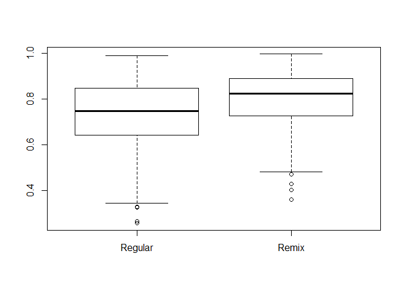

```r
boxplot(paired_energy$Energy_Regular, paired_energy$Energy_Remix,
        names = c("Regular", "Remix"))
```

```r
t.test(x = paired_energy$Energy_Remix,
       y = paired_energy$Energy_Regular,
       paired = TRUE, alternative = "greater")
```

```
##
##  Paired t-test
##
## data:  paired_energy$Energy_Remix and paired_energy$Energy_Regular
## t = 9.3152, df = 359, p-value < 2.2e-16
## alternative hypothesis: true difference in means is greater than 0
## 95 percent confidence interval:
##  0.05924437        Inf
## sample estimates:
## mean of the differences
##              0.07198889
```

**Conclusion:** as we can see, there are difference in means of the two versions, so we reject the null hypothesis and we conclude that the energy of the remix version is higher.

Let’s make another paired t.test.

### Paired t.test for speechines of the song

$H_0$ : remix version values and regular version values are the same.  
$H_1$ : remix version values are lesser than regular version values.

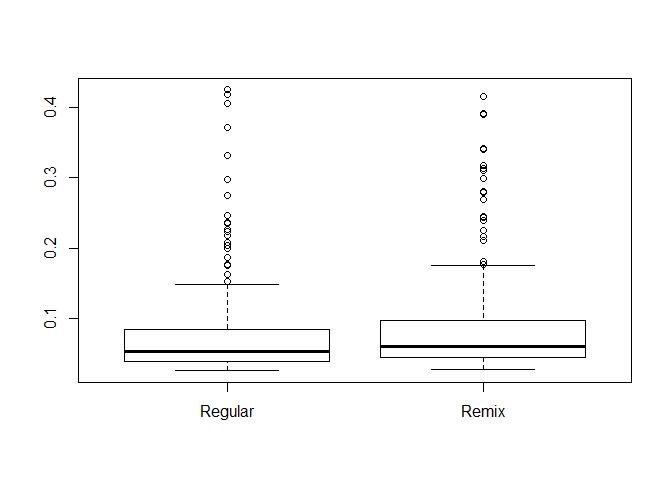

```r
boxplot(paired_speechines$speechiness_y,paired_speechines$speechiness_x,
        names = c("Regular", "Remix"))
```

```r
t.test(x = paired_speechines$speechiness_x,
       y = paired_speechines$speechiness_y,
       paired = TRUE, alternative = "less")
```

```
##
##  Paired t-test
##
## data:  paired_speechines$speechiness_x and paired_speechines$speechiness_y
## t = 2.1623, df = 359, p-value = 0.9844
## alternative hypothesis: true difference in means is less than 0
## 95 percent confidence interval:
##        -Inf 0.01420669
## sample estimates:
## mean of the differences
##             0.008059722
```

**conclusion:** We thought that in the remix versions there will be less spoken words, but in the t.test we realized that the differences between the two versions are insignificant (mean of the differences = 0.008059722).

## Second Model - Multiple Regression

Let’s start with correlation check. correlation is interesting because it can help us find simple association rules between variables. The values range between -1.0 (negative correlation) and 1.0 (positive correlation).

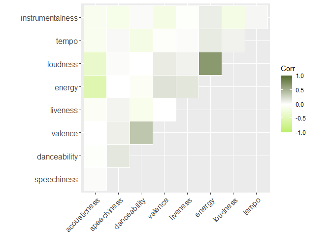

```r
numeric_tidy <- tidy_spotify %>% select(danceability,energy,valence,speechiness,acousticness
                              ,liveness,tempo,loudness,instrumentalness)

corr_data <- cor(numeric_tidy)

ggcorrplot(corr_data, hc.order = TRUE, type = "upper",
   outline.col = "white",
   ggtheme = ggplot2::theme_gray,
   colors = c("darkolivegreen2", "white", "darkolivegreen"))
```

We can see, that there is a strong positive correlation between energy and loudness. also, there is some negative correlation between loudness, energy and acousticness (it make sense!).  
Here is a demonstration of this:

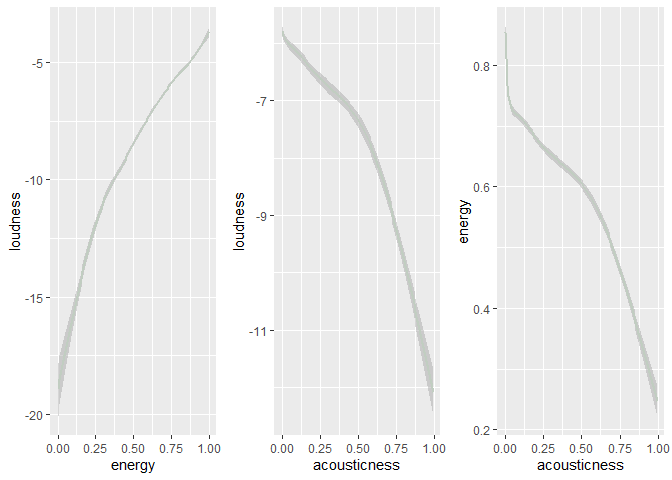

```r
energy_loudness <- ggplot(tidy_spotify, aes(x=energy, y=loudness)) +
  stat_smooth(col="honeydew3")
acousticness_loudness <- ggplot(tidy_spotify, aes(x=acousticness, y=loudness)) +
  stat_smooth(col="honeydew3")
acousticness_energy <-ggplot(tidy_spotify, aes(x=acousticness, y=energy)) +
  stat_smooth(col="honeydew3")

grid.arrange(energy_loudness, acousticness_loudness, acousticness_energy,
             nrow = 1)
```

After we saw the correlation between different variables, We will examine the multiple regression model of loudness with loudness and acousticness, loudness and energy.

```r
#multiple regression
multi <- lm(loudness~acousticness + energy,data=tidy_spotify)
summary(multi)
```

```
##
## Call:
## lm(formula = loudness ~ acousticness + energy, data = tidy_spotify)
##
## Residuals:
##      Min       1Q   Median       3Q      Max
## -22.3041  -1.0270   0.2251   1.2917   6.2873
##
## Coefficients:
##               Estimate Std. Error  t value Pr(>|t|)
## (Intercept)  -13.66833    0.09622 -142.047   <2e-16 ***
## acousticness   0.09027    0.09554    0.945    0.345
## energy        10.17675    0.11983   84.924   <2e-16 ***
## ---
## Signif. codes:  0 '***' 0.001 '**' 0.01 '*' 0.05 '.' 0.1 ' ' 1
##
## Residual standard error: 1.966 on 12274 degrees of freedom
## Multiple R-squared:  0.4483, Adjusted R-squared:  0.4482
## F-statistic:  4987 on 2 and 12274 DF,  p-value: < 2.2e-16
```

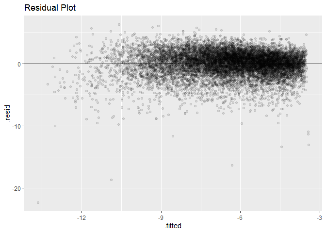

```r
resid_plot<- multi %>% ggplot(aes(x=.fitted,y=.resid)) +
  geom_point(alpha=0.1) + geom_hline(yintercept=0) +
  labs(title="Residual Plot")
resid_plot
```

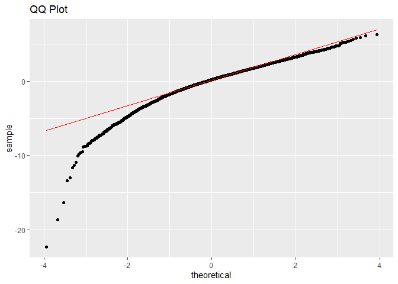

```r
resid_qq<- multi %>% ggplot(aes(sample=.resid)) +
  geom_qq() + geom_qq_line(col="red") +
  labs(title="QQ Plot")
resid_qq
```

There are two assumptions that must be:  
• residuals are homoscedastic.  
• residuals are distributed normally.

The residuals plot is looks homoscedastic.  
However, the QQ plot shows that our residuals are not distributed normal throughout the range of samples.  
Given the Adjusted R-squared and problematic distribution of residuals, the model we have created seems to be unsuitable for predicting models.

# Part Four - Discussion and summary

We have covered some techniques to manipulate or change the format of a dataframe. We have also created some basic plots such as boxplot, density, qqplot. There is much more we can do on this dataset.For instance, we can analyze the popularity of songs or artists, how popularity changes over time based on the music style. Thus, there is no limit to the exploratory data analysis process. We can approach the dataframe from a specific point of view depending on our needs. However, the techniques and operations are usually the same. So, it is better to practice with different kind of datasets.

[figure not shown]

Bonus :  
• [spotify for developers](https://developer.spotify.com/)  
• [“The Amazing Ways Spotify Uses Big Data, AI And Machine Learning To Drive Business Success”](https://www.forbes.com/sites/bernardmarr/2017/10/30/the-amazing-ways-spotify-uses-big-data-ai-and-machine-learning-to-drive-business-success/#43f99bda4bd2)